# Complement inference refinements across the MR simulation cells

- Show All Code
- Hide All Code
- View Source

Winner-only IJ variants and the simultaneous (Ĥ lower, Ĥᶜ upper) pair (TASK_complement_refinements_2026-09-06)

Author

Larry León

Published

September 6, 2026

Two additions evaluated on the `s7w` / `map1w` campaigns — the same replicates as `s7c` / `map1c`, every existing column identical (Gate 2 record):

1. **Winner-only IJ variance.** The paper’s two-term residual counts the same-draws term twice, tending to $4\sigma^2$ when one candidate dominates — the complement’s regime in every cell (IJ SE/SD 1.8–1.9). The winner-only residual $r^w_b = \mathrm{bias}_{sel} - D_{\hat H^*_b}(b)$ is the total-derivative IJ, exact when one candidate dominates and under-covering at ties on the harm side unless floored at the naive variance (`winner_floor`). Both variants are recorded beside the two-term SE.
2. **Simultaneous pair.** From the aligned field draws $(\Lambda^*_r, \Lambda^{*c}_r)$, the equal-tail level $\gamma$ with $P^*(\Lambda^* \le q_{1-\gamma},\ \Lambda^{*c} \ge q_\gamma) \ge 0.95$, against the two separate 95% bounds and the Bonferroni pair.

The displays use the Gaussian bookkeeping reference (harm block: lower bound, $\Phi(z_{0.95} r - b)$; complement block: upper bound, $\Phi(z_{0.95} r + b)$).

# 1 Knobs

```r
library(forestsearch)
library(ggplot2)
library(kableExtra)
globs <- strsplit(Sys.getenv("FS_SUMW_GLOBS",
                  "results/fs_*_s7w_combined_1_2000.rds;results/fs_*_map1w_combined_1_2000.rds"),
                  ";", fixed = TRUE)[[1]]
estimators <- c("mr", "mr_w", "mr_wf", "fld")
curves     <- c(1, 1.25, 1.5, 2)
cell_label <- function(meta, f) {
  hr <- meta$target_hr_harm
  base <- if (hr < 1) sprintf("protective %.2f", hr)
  else if (hr == 1) "null 1.0" else sprintf("harm %.4g", hr)
  kn <- as.integer(sub("^.*_knoise(\\d+)_.*$", "\\1", basename(f)))
  nn <- if (meta$n_sample == 500) if (kn > 0 || hr < 1) "" else ", n=500" else sprintf(", n=%d", meta$n_sample)
  paste0(base, nn, if (kn > 0) sprintf(", %d noise", kn) else "")
}
files <- sort(unlist(lapply(globs, Sys.glob)))
stopifnot(length(files) > 0)
bundles <- lapply(files, readRDS)
labels  <- mapply(cell_label, lapply(bundles, `[[`, "meta"), files)
```

# 2 Complement block (one-sided = upper bound)

```r
tabC <- do.call(rbind, lapply(seq_along(bundles), function(i) {
  s <- fs_sim_bias_coverage(bundles[[i]]$results, block = "Hc", estimators = estimators, side = "upper")
  s$cell <- labels[i]; s
}))
tabC$estimator <- factor(tabC$estimator, levels = c("naive", "mr", "mr_w", "mr_wf", "fld"),
                         labels = c("naive", "IJ two-term", "IJ winner", "IJ winner-floor", "field"))
kbl(tabC[, c("cell", "estimator", "n", "b", "r", "cov1", "cov1_wilson_lo", "cov1_wilson_hi",
             "cov2", "cov2_wilson_lo", "cov2_wilson_hi", "cov1_ref", "cov2_ref")],
    digits = 3, booktabs = TRUE, row.names = FALSE,
    caption = "Complement block; cov1 = one-sided 95% UPPER-bound coverage of beta(Hhat^c).") |>
  kable_styling(font_size = 12)
```

Complement block; cov1 = one-sided 95% UPPER-bound coverage of beta(Hhat^c).

| cell | estimator | n | b | r | cov1 | cov1_wilson_lo | cov1_wilson_hi | cov2 | cov2_wilson_lo | cov2_wilson_hi | cov1_ref | cov2_ref |
| --- | --- | --- | --- | --- | --- | --- | --- | --- | --- | --- | --- | --- |
| protective 0.75 | IJ two-term | 1042 | -0.123 | 1.843 | 0.995 | 0.989 | 0.998 | 1.000 | 0.996 | 1.000 | 0.998 | 1.000 |
| protective 0.75 | IJ winner | 1042 | -0.123 | 0.888 | 0.899 | 0.879 | 0.916 | 0.915 | 0.896 | 0.930 | 0.910 | 0.916 |
| protective 0.75 | IJ winner-floor | 1042 | -0.123 | 1.014 | 0.934 | 0.917 | 0.947 | 0.955 | 0.941 | 0.966 | 0.939 | 0.951 |
| protective 0.75 | field | 1042 | -0.039 | 0.960 | 0.936 | 0.919 | 0.949 | 0.943 | 0.928 | 0.956 | 0.938 | 0.940 |
| null 1.0, n=1000 | IJ two-term | 1319 | 0.004 | 1.854 | 0.998 | 0.993 | 0.999 | 1.000 | 0.997 | 1.000 | 0.999 | 1.000 |
| null 1.0, n=1000 | IJ winner | 1319 | 0.004 | 0.900 | 0.939 | 0.924 | 0.950 | 0.927 | 0.912 | 0.940 | 0.931 | 0.922 |
| null 1.0, n=1000 | IJ winner-floor | 1319 | 0.004 | 1.000 | 0.953 | 0.940 | 0.963 | 0.958 | 0.945 | 0.967 | 0.950 | 0.950 |
| null 1.0, n=1000 | field | 1319 | 0.077 | 0.958 | 0.953 | 0.940 | 0.963 | 0.945 | 0.932 | 0.956 | 0.951 | 0.939 |
| null 1.0, n=500 | IJ two-term | 1361 | -0.156 | 1.854 | 0.997 | 0.992 | 0.999 | 1.000 | 0.997 | 1.000 | 0.998 | 1.000 |
| null 1.0, n=500 | IJ winner | 1361 | -0.156 | 0.893 | 0.896 | 0.878 | 0.911 | 0.917 | 0.901 | 0.930 | 0.906 | 0.916 |
| null 1.0, n=500 | IJ winner-floor | 1361 | -0.156 | 1.015 | 0.932 | 0.917 | 0.944 | 0.954 | 0.941 | 0.964 | 0.935 | 0.951 |
| null 1.0, n=500 | field | 1361 | -0.069 | 0.966 | 0.930 | 0.915 | 0.943 | 0.950 | 0.937 | 0.960 | 0.936 | 0.941 |
| harm 1.5, n=1500 | IJ two-term | 1976 | 0.081 | 1.837 | 0.999 | 0.996 | 1.000 | 0.999 | 0.996 | 1.000 | 0.999 | 1.000 |
| harm 1.5, n=1500 | IJ winner | 1976 | 0.081 | 0.891 | 0.945 | 0.934 | 0.954 | 0.936 | 0.924 | 0.946 | 0.939 | 0.918 |
| harm 1.5, n=1500 | IJ winner-floor | 1976 | 0.081 | 0.968 | 0.960 | 0.950 | 0.968 | 0.953 | 0.943 | 0.962 | 0.953 | 0.941 |
| harm 1.5, n=1500 | field | 1976 | 0.081 | 0.941 | 0.956 | 0.947 | 0.965 | 0.946 | 0.936 | 0.955 | 0.948 | 0.934 |
| harm 1.5, n=500 | IJ two-term | 1822 | -0.105 | 1.813 | 0.997 | 0.993 | 0.998 | 1.000 | 0.998 | 1.000 | 0.998 | 1.000 |
| harm 1.5, n=500 | IJ winner | 1822 | -0.105 | 0.873 | 0.905 | 0.891 | 0.918 | 0.917 | 0.903 | 0.928 | 0.908 | 0.911 |
| harm 1.5, n=500 | IJ winner-floor | 1822 | -0.105 | 0.981 | 0.938 | 0.926 | 0.948 | 0.951 | 0.940 | 0.960 | 0.934 | 0.944 |
| harm 1.5, n=500 | field | 1822 | -0.036 | 0.938 | 0.936 | 0.924 | 0.947 | 0.935 | 0.923 | 0.946 | 0.934 | 0.934 |
| harm 1.75, n=500 | IJ two-term | 1900 | -0.058 | 1.800 | 0.999 | 0.996 | 1.000 | 1.000 | 0.998 | 1.000 | 0.998 | 1.000 |
| harm 1.75, n=500 | IJ winner | 1900 | -0.058 | 0.866 | 0.913 | 0.899 | 0.925 | 0.914 | 0.901 | 0.926 | 0.914 | 0.910 |
| harm 1.75, n=500 | IJ winner-floor | 1900 | -0.058 | 0.969 | 0.938 | 0.927 | 0.948 | 0.947 | 0.936 | 0.957 | 0.938 | 0.942 |
| harm 1.75, n=500 | field | 1900 | -0.004 | 0.927 | 0.936 | 0.924 | 0.946 | 0.934 | 0.922 | 0.944 | 0.936 | 0.931 |
| harm 1.75, 3 noise | IJ two-term | 1311 | -0.079 | 1.833 | 0.998 | 0.994 | 1.000 | 1.000 | 0.997 | 1.000 | 0.998 | 1.000 |
| harm 1.75, 3 noise | IJ winner | 1311 | -0.079 | 0.884 | 0.908 | 0.891 | 0.922 | 0.912 | 0.896 | 0.926 | 0.916 | 0.916 |
| harm 1.75, 3 noise | IJ winner-floor | 1311 | -0.079 | 0.987 | 0.938 | 0.924 | 0.950 | 0.947 | 0.934 | 0.958 | 0.939 | 0.946 |
| harm 1.75, 3 noise | field | 1311 | -0.012 | 0.945 | 0.937 | 0.923 | 0.949 | 0.937 | 0.922 | 0.949 | 0.938 | 0.936 |

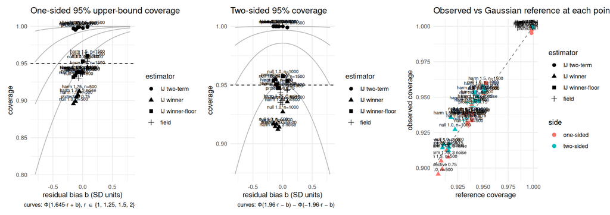

```r
fs_plot_bias_coverage(tabC, curves = curves, side = "upper")
```

# 3 Harm block (one-sided = lower bound)

```r
tabH <- do.call(rbind, lapply(seq_along(bundles), function(i) {
  s <- fs_sim_bias_coverage(bundles[[i]]$results, block = "H", estimators = estimators, side = "lower")
  s$cell <- labels[i]; s
}))
tabH$estimator <- factor(tabH$estimator, levels = c("naive", "mr", "mr_w", "mr_wf", "fld"),
                         labels = c("naive", "IJ two-term", "IJ winner", "IJ winner-floor", "field"))
kbl(tabH[, c("cell", "estimator", "n", "b", "r", "cov1", "cov1_wilson_lo", "cov1_wilson_hi",
             "cov2", "cov2_wilson_lo", "cov2_wilson_hi", "cov1_ref", "cov2_ref")],
    digits = 3, booktabs = TRUE, row.names = FALSE,
    caption = "Harm block; cov1 = one-sided 95% LOWER-bound coverage of beta(Hhat).") |>
  kable_styling(font_size = 12)
```

Harm block; cov1 = one-sided 95% LOWER-bound coverage of beta(Hhat).

| cell | estimator | n | b | r | cov1 | cov1_wilson_lo | cov1_wilson_hi | cov2 | cov2_wilson_lo | cov2_wilson_hi | cov1_ref | cov2_ref |
| --- | --- | --- | --- | --- | --- | --- | --- | --- | --- | --- | --- | --- |
| protective 0.75 | IJ two-term | 1042 | 1.574 | 1.961 | 0.964 | 0.950 | 0.973 | 0.984 | 0.974 | 0.990 | 0.951 | 0.988 |
| protective 0.75 | IJ winner | 1042 | 1.574 | 0.855 | 0.465 | 0.435 | 0.496 | 0.559 | 0.528 | 0.588 | 0.434 | 0.540 |
| protective 0.75 | IJ winner-floor | 1042 | 1.574 | 1.609 | 0.876 | 0.855 | 0.895 | 0.944 | 0.929 | 0.957 | 0.858 | 0.943 |
| protective 0.75 | field | 1042 | 0.908 | 1.537 | 0.953 | 0.938 | 0.964 | 0.988 | 0.980 | 0.993 | 0.947 | 0.982 |
| null 1.0, n=1000 | IJ two-term | 1319 | 0.944 | 1.560 | 0.936 | 0.922 | 0.948 | 0.980 | 0.971 | 0.987 | 0.948 | 0.983 |
| null 1.0, n=1000 | IJ winner | 1319 | 0.944 | 0.652 | 0.549 | 0.522 | 0.576 | 0.585 | 0.558 | 0.611 | 0.551 | 0.618 |
| null 1.0, n=1000 | IJ winner-floor | 1319 | 0.944 | 1.316 | 0.882 | 0.863 | 0.898 | 0.938 | 0.923 | 0.950 | 0.889 | 0.949 |
| null 1.0, n=1000 | field | 1319 | 0.489 | 1.225 | 0.920 | 0.905 | 0.934 | 0.958 | 0.945 | 0.967 | 0.937 | 0.970 |
| null 1.0, n=500 | IJ two-term | 1361 | 1.098 | 1.794 | 0.966 | 0.955 | 0.975 | 0.986 | 0.978 | 0.991 | 0.968 | 0.992 |
| null 1.0, n=500 | IJ winner | 1361 | 1.098 | 0.786 | 0.580 | 0.553 | 0.606 | 0.642 | 0.616 | 0.667 | 0.577 | 0.667 |
| null 1.0, n=500 | IJ winner-floor | 1361 | 1.098 | 1.456 | 0.892 | 0.874 | 0.907 | 0.950 | 0.937 | 0.960 | 0.903 | 0.960 |
| null 1.0, n=500 | field | 1361 | 0.556 | 1.410 | 0.963 | 0.951 | 0.971 | 0.988 | 0.981 | 0.993 | 0.961 | 0.986 |
| harm 1.5, n=1500 | IJ two-term | 1976 | -0.371 | 1.082 | 0.981 | 0.974 | 0.986 | 0.901 | 0.887 | 0.913 | 0.984 | 0.954 |
| harm 1.5, n=1500 | IJ winner | 1976 | -0.371 | 0.487 | 0.863 | 0.848 | 0.878 | 0.573 | 0.551 | 0.595 | 0.879 | 0.627 |
| harm 1.5, n=1500 | IJ winner-floor | 1976 | -0.371 | 0.808 | 0.941 | 0.930 | 0.951 | 0.810 | 0.792 | 0.826 | 0.955 | 0.862 |
| harm 1.5, n=1500 | field | 1976 | -0.334 | 0.890 | 0.956 | 0.947 | 0.965 | 0.848 | 0.832 | 0.863 | 0.964 | 0.902 |
| harm 1.5, n=500 | IJ two-term | 1822 | 0.213 | 1.431 | 0.978 | 0.970 | 0.984 | 0.977 | 0.969 | 0.983 | 0.984 | 0.994 |
| harm 1.5, n=500 | IJ winner | 1822 | 0.213 | 0.643 | 0.727 | 0.706 | 0.747 | 0.626 | 0.604 | 0.648 | 0.801 | 0.782 |
| harm 1.5, n=500 | IJ winner-floor | 1822 | 0.213 | 1.143 | 0.926 | 0.914 | 0.938 | 0.923 | 0.910 | 0.935 | 0.952 | 0.972 |
| harm 1.5, n=500 | field | 1822 | -0.066 | 1.137 | 0.965 | 0.956 | 0.973 | 0.919 | 0.905 | 0.930 | 0.974 | 0.974 |
| harm 1.75, n=500 | IJ two-term | 1900 | -0.032 | 1.260 | 0.983 | 0.976 | 0.988 | 0.961 | 0.951 | 0.969 | 0.982 | 0.986 |
| harm 1.75, n=500 | IJ winner | 1900 | -0.032 | 0.575 | 0.767 | 0.748 | 0.786 | 0.607 | 0.585 | 0.629 | 0.836 | 0.740 |
| harm 1.75, n=500 | IJ winner-floor | 1900 | -0.032 | 0.994 | 0.929 | 0.917 | 0.940 | 0.889 | 0.874 | 0.902 | 0.952 | 0.948 |
| harm 1.75, n=500 | field | 1900 | -0.209 | 1.014 | 0.966 | 0.957 | 0.974 | 0.887 | 0.872 | 0.901 | 0.970 | 0.948 |
| harm 1.75, 3 noise | IJ two-term | 1311 | -0.221 | 1.335 | 0.982 | 0.973 | 0.988 | 0.950 | 0.937 | 0.961 | 0.992 | 0.989 |
| harm 1.75, 3 noise | IJ winner | 1311 | -0.221 | 0.596 | 0.798 | 0.775 | 0.819 | 0.603 | 0.577 | 0.629 | 0.885 | 0.746 |
| harm 1.75, 3 noise | IJ winner-floor | 1311 | -0.221 | 1.080 | 0.950 | 0.936 | 0.960 | 0.880 | 0.862 | 0.897 | 0.977 | 0.961 |
| harm 1.75, 3 noise | field | 1311 | -0.420 | 1.070 | 0.981 | 0.972 | 0.987 | 0.866 | 0.846 | 0.883 | 0.985 | 0.947 |

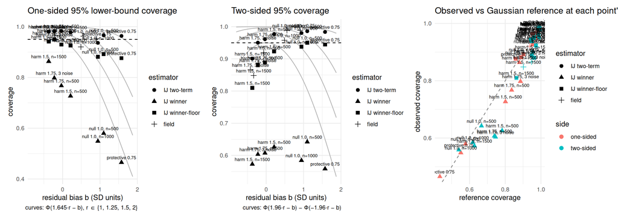

```r
fs_plot_bias_coverage(tabH, curves = curves, side = "lower")
```

# 4 The simultaneous pair

```r
wil <- function(x, n, z = qnorm(.975)) { c <- (x + z^2/(2*n))/(1+z^2/n); h <- z*sqrt(x*(1-x)/n + z^2/(4*n^2))/(1+z^2/n); c(c - h, c + h) }
tabJ <- do.call(rbind, lapply(seq_along(bundles), function(i) {
  r <- bundles[[i]]$results; d <- r[r$detected %in% 1L, ]
  d <- d[is.finite(d$betaHhat_H) & is.finite(d$betaHhat_Hc) & is.finite(d$fld_joint_gamma), ]
  pairs <- list(`separate 95%` = list(lo = d$fld_H_lo1s, up = d$fld_Hc_up1s),
                `Bonferroni`   = list(lo = d$fld_joint_bonf_loH, up = d$fld_joint_bonf_upHc),
                `calibrated`   = list(lo = d$fld_joint_loH, up = d$fld_joint_upHc))
  do.call(rbind, lapply(names(pairs), function(nm) { p <- pairs[[nm]]
    cH <- d$betaHhat_H >= p$lo; cC <- d$betaHhat_Hc <= p$up; jc <- mean(cH & cC); w <- wil(jc, nrow(d))
    data.frame(cell = labels[i], pair = nm, n = nrow(d), joint_cov = jc, wilson_lo = w[1], wilson_hi = w[2],
               cov_H = mean(cH), cov_Hc = mean(cC),
               margin_H = mean(log(d$mr_H_est) - log(p$lo)), margin_Hc = mean(log(p$up) - log(d$mr_Hc_est)),
               mean_gamma = mean(d$fld_joint_gamma), mean_corr = mean(d$fld_joint_corr), stringsAsFactors = FALSE) }))
}))
kbl(tabJ, digits = 3, booktabs = TRUE, row.names = FALSE,
    caption = "Joint coverage of (beta(Hhat) >= lower_H, beta(Hhat^c) <= upper_Hc) with Wilson intervals; margins on the log scale from the two-term de-biased estimates.") |>
  kable_styling(font_size = 12)
```

Joint coverage of (beta(Hhat) >= lower_H, beta(Hhat^c) <= upper_Hc) with Wilson intervals; margins on the log scale from the two-term de-biased estimates.

| cell | pair | n | joint_cov | wilson_lo | wilson_hi | cov_H | cov_Hc | margin_H | margin_Hc | mean_gamma | mean_corr |
| --- | --- | --- | --- | --- | --- | --- | --- | --- | --- | --- | --- |
| protective 0.75 | separate 95% | 1042 | 0.890 | 0.869 | 0.907 | 0.953 | 0.936 | 0.747 | 0.236 | 0.025 | 0.044 |
| protective 0.75 | Bonferroni | 1042 | 0.950 | 0.935 | 0.962 | 0.988 | 0.962 | 0.896 | 0.280 | 0.025 | 0.044 |
| protective 0.75 | calibrated | 1042 | 0.950 | 0.935 | 0.962 | 0.988 | 0.962 | 0.896 | 0.280 | 0.025 | 0.044 |
| null 1.0, n=1000 | separate 95% | 1319 | 0.876 | 0.858 | 0.893 | 0.920 | 0.953 | 0.542 | 0.164 | 0.025 | 0.038 |
| null 1.0, n=1000 | Bonferroni | 1319 | 0.940 | 0.926 | 0.952 | 0.961 | 0.978 | 0.650 | 0.194 | 0.025 | 0.038 |
| null 1.0, n=1000 | calibrated | 1319 | 0.940 | 0.926 | 0.952 | 0.961 | 0.978 | 0.650 | 0.194 | 0.025 | 0.038 |
| null 1.0, n=500 | separate 95% | 1361 | 0.894 | 0.877 | 0.909 | 0.963 | 0.930 | 0.734 | 0.236 | 0.025 | 0.047 |
| null 1.0, n=500 | Bonferroni | 1361 | 0.955 | 0.943 | 0.965 | 0.988 | 0.967 | 0.883 | 0.279 | 0.025 | 0.047 |
| null 1.0, n=500 | calibrated | 1361 | 0.955 | 0.943 | 0.965 | 0.988 | 0.967 | 0.883 | 0.279 | 0.025 | 0.047 |
| harm 1.5, n=1500 | separate 95% | 1976 | 0.916 | 0.903 | 0.927 | 0.956 | 0.956 | 0.398 | 0.130 | 0.025 | -0.049 |
| harm 1.5, n=1500 | Bonferroni | 1976 | 0.957 | 0.947 | 0.965 | 0.974 | 0.982 | 0.484 | 0.155 | 0.025 | -0.049 |
| harm 1.5, n=1500 | calibrated | 1976 | 0.957 | 0.947 | 0.965 | 0.974 | 0.982 | 0.483 | 0.155 | 0.025 | -0.049 |
| harm 1.5, n=500 | separate 95% | 1822 | 0.905 | 0.891 | 0.918 | 0.965 | 0.936 | 0.710 | 0.233 | 0.025 | 0.030 |
| harm 1.5, n=500 | Bonferroni | 1822 | 0.953 | 0.942 | 0.962 | 0.990 | 0.963 | 0.858 | 0.276 | 0.025 | 0.030 |
| harm 1.5, n=500 | calibrated | 1822 | 0.953 | 0.942 | 0.962 | 0.990 | 0.963 | 0.858 | 0.276 | 0.025 | 0.030 |
| harm 1.75, n=500 | separate 95% | 1900 | 0.905 | 0.891 | 0.918 | 0.966 | 0.936 | 0.699 | 0.232 | 0.025 | 0.014 |
| harm 1.75, n=500 | Bonferroni | 1900 | 0.956 | 0.946 | 0.964 | 0.990 | 0.965 | 0.847 | 0.275 | 0.025 | 0.014 |
| harm 1.75, n=500 | calibrated | 1900 | 0.956 | 0.946 | 0.964 | 0.990 | 0.965 | 0.846 | 0.275 | 0.025 | 0.014 |
| harm 1.75, 3 noise | separate 95% | 1311 | 0.919 | 0.903 | 0.933 | 0.981 | 0.937 | 0.711 | 0.232 | 0.025 | 0.027 |
| harm 1.75, 3 noise | Bonferroni | 1311 | 0.960 | 0.948 | 0.970 | 0.993 | 0.967 | 0.858 | 0.275 | 0.025 | 0.027 |
| harm 1.75, 3 noise | calibrated | 1311 | 0.960 | 0.947 | 0.969 | 0.993 | 0.966 | 0.857 | 0.274 | 0.025 | 0.027 |

# 5 Reading

Complement, one-sided upper coverage: IJ two-term 0.995/0.998/0.997/0.999/0.997/0.999/0.998 (r = 1.84/1.85/1.85/1.84/1.81/1.80/1.83); IJ winner 0.899/0.939/0.896/0.945/0.905/0.913/0.908 (r = 0.89/0.90/0.89/0.89/0.87/0.87/0.88); IJ winner-floor 0.934/0.953/0.932/0.960/0.938/0.938/0.938 (r = 1.01/1.00/1.01/0.97/0.98/0.97/0.99); field 0.936/0.953/0.930/0.956/0.936/0.936/0.937 (r = 0.96/0.96/0.97/0.94/0.94/0.93/0.94). Harm, one-sided lower coverage: IJ two-term 0.964/0.936/0.966/0.981/0.978/0.983/0.982; IJ winner 0.465/0.549/0.580/0.863/0.727/0.767/0.798 (r = 0.86/0.65/0.79/0.49/0.64/0.57/0.60); IJ winner-floor 0.876/0.882/0.892/0.941/0.926/0.929/0.950 (r = 1.61/1.32/1.46/0.81/1.14/0.99/1.08); field 0.953/0.920/0.963/0.956/0.965/0.966/0.981. Joint pair: calibrated coverage 0.950/0.940/0.955/0.957/0.953/0.956/0.960 (mean gamma 0.0250/0.0250/0.0250/0.0251/0.0251/0.0251/0.0251, mean corr +0.044/+0.038/+0.047/-0.049/+0.030/+0.014/+0.027) vs Bonferroni 0.950/0.940/0.955/0.957/0.953/0.956/0.960 vs separate 95% bounds 0.890/0.876/0.894/0.916/0.905/0.905/0.919; calibrated margins H 0.896/0.650/0.883/0.483/0.858/0.846/0.857 / Hc 0.280/0.194/0.279/0.155/0.276/0.275/0.274 vs Bonferroni 0.896/0.650/0.883/0.484/0.858/0.847/0.858 / 0.280/0.194/0.279/0.155/0.276/0.275/0.275.